# Analyzing Individual BGG Users

Phil Henrickson

2022-01-02

# **SteadyLark’s** BoardGameGeek Collection

This notebook contains a set of analyses for the selected user’s boardgamegeek collection. The bulk of the analysis is focused on building a user-specific predictive model to predict the games that SteadyLark is likely to own. This enables to ask questions like, based on the games the user currently owns, what games are a good fit for their collection? What upcoming games are they likely to purchase?

This analysis is based on data from BoardGameGeek that was last updated on **2021-12-20.**

# 1 Collection Overview

We can look at a basic description of the number of games that the user owns, has rated, has previously owned, etc.

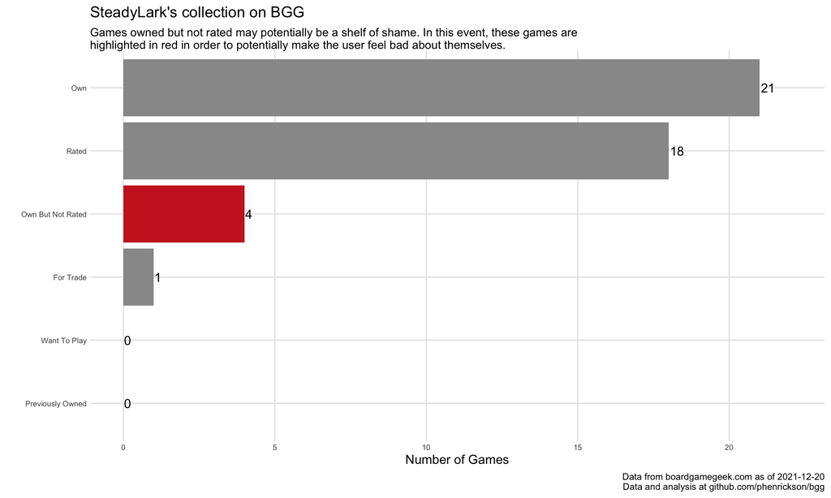

What years has the user owned/rated games from? While we can’t see when a user added or removed a game from their collection, we can look at their collection by the years in which their games were published.

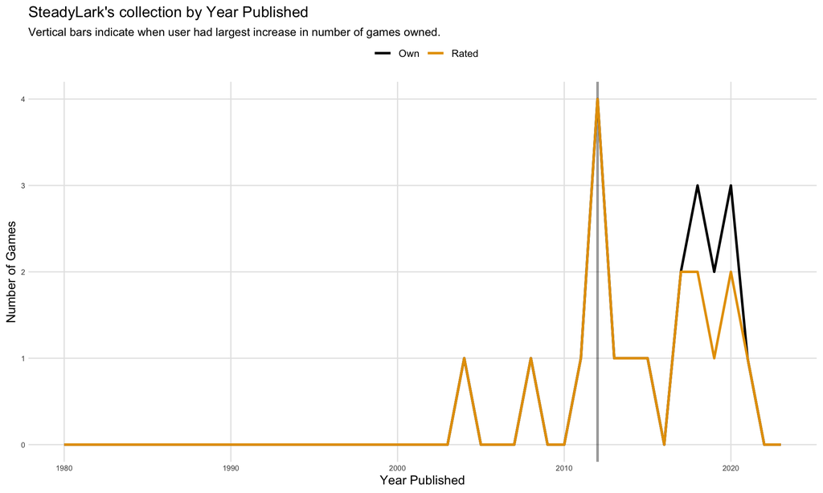

## 1.1 What types of games does SteadyLark own?

We can look at the most frequent types of categories, mechanics, designers, and artists that appear in a user’s collection.

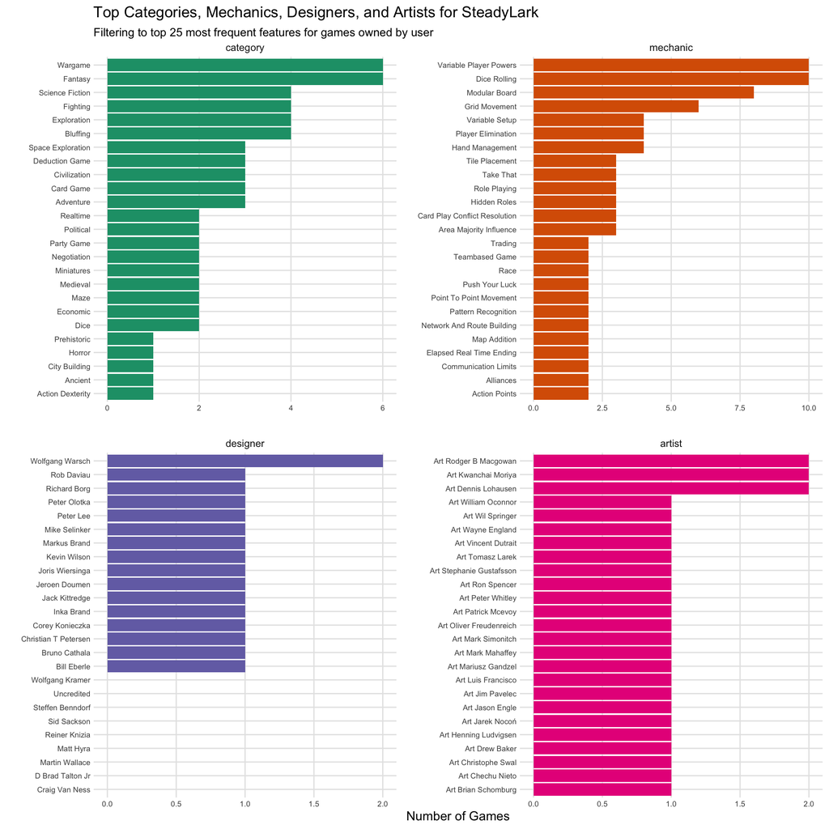

# 2 Modeling **SteadyLark’s** Collection

| username | dataset | period | games_owned | games_rated | games_played |
| --- | --- | --- | --- | --- | --- |
| SteadyLark | training | published before 2020 | 17 | 15 | 18 |
| SteadyLark | test | published 2020 or later | 4 | 3 | 4 |

There are two main (binary) outcomes we will be modeling for the user.

The first, **own** refers to whether the user currently lists a game as owned in their collection. The second, **played** refers to whether the user currently owns, has rated, or previously owned a game. This means the latter will generally have a larger list of games, but may still be a useful category to examine for people who play lots of games without necessarily owning them.

We will train predictive models to learn the probability that the user will own or play individual games based on their features.

## 2.1 Coefficients for SteadyLark

We can examine coefficients from the trained modes, which are penalized logistic regressions fit to our two main outcomes. Positive values indicate that a feature increases a user’s probabilility of owning/rating a game, while negative values indicate a feature decreases the probability.

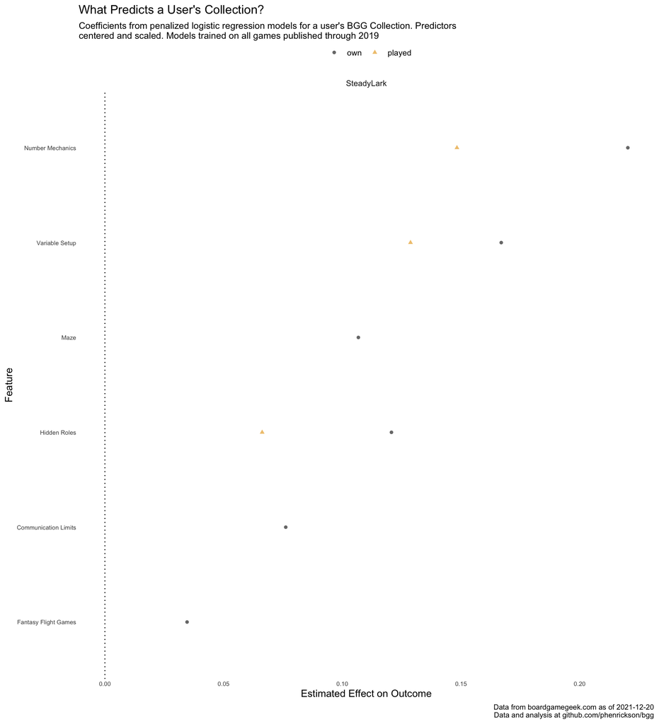

## 2.2 Visualizing Predictors for SteadyLark’s Collection

Why did the model identify these features? We can make density plots of the important features for predicting whether the user owned a game. Blue indicates the density for games owned by the user, while grey indicates the density for games not owned by the user.

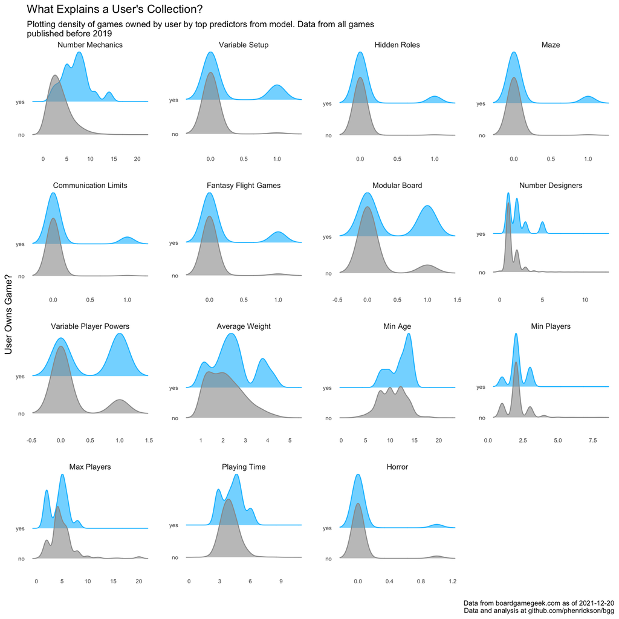

Binary predictors can be difficult to see with this visualization, so we can also directly examine the percentage of games in a user’s collection with a predictor vs the percentage of all games with that predictor.

| username | Feature | % of Games with Feature In_Collection | % of Games with Feature All_Games | Ratio |
| --- | --- | --- | --- | --- |
| SteadyLark | Hidden Roles | 11.8% | 0.7% | 16.5 |
| SteadyLark | Maze | 11.8% | 0.9% | 13.2 |
| SteadyLark | Variable Setup | 23.5% | 1.9% | 12.6 |
| SteadyLark | Communication Limits | 11.8% | 1.0% | 12.0 |
| SteadyLark | Fantasy Flight Games | 17.6% | 2.6% | 6.7 |
| SteadyLark | Prehistoric | 5.9% | 1.0% | 5.7 |
| SteadyLark | Modular Board | 41.2% | 10.9% | 3.8 |
| SteadyLark | Negotiation | 11.8% | 3.6% | 3.2 |
| SteadyLark | Variable Player Powers | 52.9% | 17.0% | 3.1 |
| SteadyLark | Medieval | 11.8% | 6.3% | 1.9 |
| SteadyLark | Deduction Game | 11.8% | 6.4% | 1.8 |
| SteadyLark | Horror | 5.9% | 4.0% | 1.5 |
| SteadyLark | City Building | 5.9% | 4.3% | 1.4 |
| SteadyLark | Realtime | 5.9% | 4.2% | 1.4 |
| SteadyLark | Action Dexterity | 5.9% | 4.8% | 1.2 |
| SteadyLark | Party Game | 5.9% | 8.5% | 0.7 |
| SteadyLark | Word Game | 0.0% | 1.8% | 0.0 |
| SteadyLark | Trivia | 0.0% | 1.8% | 0.0 |
| SteadyLark | Puzzle | 0.0% | 3.4% | 0.0 |
| SteadyLark | Racing | 0.0% | 2.8% | 0.0 |
| SteadyLark | Mafia | 0.0% | 0.7% | 0.0 |
| SteadyLark | Trains | 0.0% | 2.2% | 0.0 |
| SteadyLark | Sports | 0.0% | 2.0% | 0.0 |
| SteadyLark | Murdermystery | 0.0% | 1.8% | 0.0 |
| SteadyLark | Childrens Game | 0.0% | 5.7% | 0.0 |

# 3 Assess Model’s Performance on Training Set

Before predicting games in upcoming years, we can examine how well the model did and what games it liked in the training set. In this case, we used resampling techniques (cross validation) to ensure that the model had not seen a game before making its predictions.

## 3.1 Separation Plot

An easy way to examine the performance of classification model is to view a separation plot. We plot the predicted probabilities from the model for every game (from resampling) from lowest to highest. We then overlay a blue line for any game that the user does own. A good classifier is one that is able to *separate* the blue (games owned by the user) from the white (games not owned by the user), with most of the blue occurring at the highest probabilities (right side of the chart).

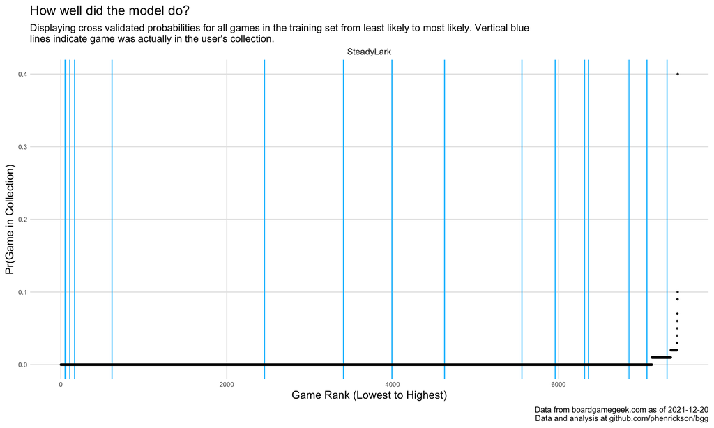

## 3.2 Top Games for **SteadyLark** from Training Set

We can display this information in table form, displaying the 100 games with the highest probability of ownership, adding a blue line when the user does own the game.

| username | yearpublished | game_id | name | pred_played | pred_own | actual_played | actual_own |
| --- | --- | --- | --- | --- | --- | --- | --- |
| SteadyLark | 2008 | 37111 | Battlestar Galactica: The Board Game | 0.12 | 0.40 | 0 | 0 |
| SteadyLark | 1979 | 3625 | DeathMaze | 0.02 | 0.10 | 0 | 0 |
| SteadyLark | 2015 | 172996 | The King Is Dead | 0.02 | 0.09 | 0 | 0 |
| SteadyLark | 2007 | 29937 | König von Siam | 0.02 | 0.09 | 0 | 0 |
| SteadyLark | 2012 | 104710 | Wiz-War (Eighth Edition) | 0.03 | 0.07 | 0 | 0 |
| SteadyLark | 2017 | 174430 | Gloomhaven | 0.02 | 0.07 | 0 | 0 |
| SteadyLark | 2011 | 102548 | Dungeon Fighter | 0.02 | 0.06 | 0 | 0 |
| SteadyLark | 2019 | 274093 | Quirky Circuits | 0.02 | 0.05 | 0 | 0 |
| SteadyLark | 2016 | 198454 | When I Dream | 0.02 | 0.04 | 0 | 0 |
| SteadyLark | 2010 | 82168 | Escape from the Aliens in Outer Space | 0.02 | 0.03 | 0 | 0 |
| SteadyLark | 2015 | 171630 | Drakon (Fourth Edition) | 0.01 | 0.03 | 0 | 0 |
| SteadyLark | 1973 | 2995 | Sniper! | 0.01 | 0.02 | 0 | 0 |
| SteadyLark | 1977 | 2529 | Flat Top | 0.02 | 0.02 | 0 | 0 |
| SteadyLark | 2017 | 217083 | LYNGK | 0.01 | 0.02 | 0 | 0 |
| SteadyLark | 1983 | 2079 | NATO: The Next War in Europe | 0.01 | 0.02 | 0 | 0 |
| SteadyLark | 2019 | 279644 | Peloponnesian War | 0.01 | 0.02 | 0 | 0 |
| SteadyLark | 2017 | 216658 | Smash Up: What Were We Thinking? | 0.01 | 0.02 | 0 | 0 |
| SteadyLark | 1964 | 2250 | Midway | 0.01 | 0.02 | 0 | 0 |
| SteadyLark | 1976 | 3041 | Panzergruppe Guderian | 0.01 | 0.02 | 0 | 0 |
| SteadyLark | 1985 | 243 | Advanced Squad Leader | 0.01 | 0.02 | 0 | 0 |
| SteadyLark | 1977 | 4008 | Cobra: Game of the Normandy Breakout | 0.02 | 0.02 | 0 | 0 |
| SteadyLark | 1983 | 2081 | The Civil War 1861-1865 | 0.01 | 0.02 | 0 | 0 |
| SteadyLark | 1978 | 1773 | Dawn of the Dead | 0.01 | 0.02 | 0 | 0 |
| SteadyLark | 2016 | 196340 | Yokohama | 0.01 | 0.02 | 0 | 0 |
| SteadyLark | 2018 | 237182 | Root | 0.01 | 0.02 | 0 | 0 |
| SteadyLark | 2019 | 283294 | Yukon Airways | 0.01 | 0.02 | 0 | 0 |
| SteadyLark | 2010 | 25292 | Merchants & Marauders | 0.01 | 0.02 | 0 | 0 |
| SteadyLark | 2010 | 73171 | Earth Reborn | 0.01 | 0.02 | 0 | 0 |
| SteadyLark | 2017 | 193728 | Pendragon: The Fall of Roman Britain | 0.01 | 0.02 | 0 | 0 |
| SteadyLark | 1980 | 1152 | The Mystic Wood | 0.01 | 0.02 | 0 | 0 |

[output cut: 70 more lines]

We can also more formally assess how well the model did in resampling by looking at the area under the receiver operating characteristic. A perfect model would receive a score of 1, while a model that cannot predict the outcome will default to a score of 0.5. The extent to which something is a *good* score depends on the setting, but generally anything in the .8 to .9 range is very good while the .7 to .8 range is perfectly acceptable.

| username | outcome_type | .metric | .estimator | .estimate |
| --- | --- | --- | --- | --- |
| SteadyLark | own | roc_auc | binary | 0.648 |
| SteadyLark | played | roc_auc | binary | 0.645 |

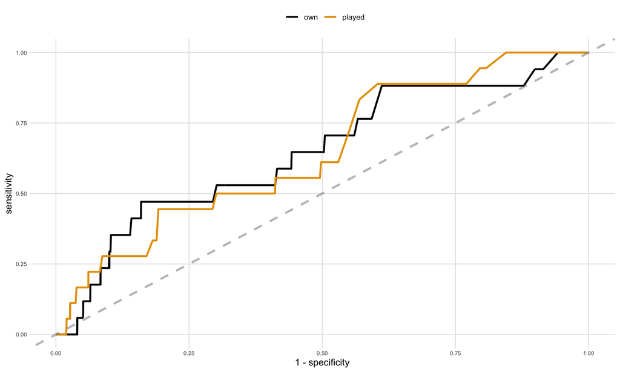

Another way to think about the model performance is to view its lift, or its ability to detect the positive outcomes over that of a null model. High lift indicates the model can much more quickly find all of the positive outcomes (in this case, games owned or played by the user), while a model with no lift is no better than random guessing.

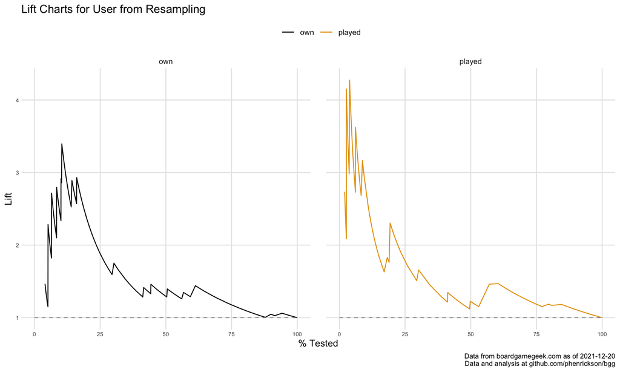

## 3.3 Most and Least Likely Games

What games does the model think SteadyLark is **most likely to own** that are **not** in their collection?

| username | yearpublished | game_id | name | pred_own | actual_own |
| --- | --- | --- | --- | --- | --- |
| SteadyLark | 2008 | 37111 | Battlestar Galactica: The Board Game | 0.40 | 0 |
| SteadyLark | 1979 | 3625 | DeathMaze | 0.10 | 0 |
| SteadyLark | 2015 | 172996 | The King Is Dead | 0.09 | 0 |
| SteadyLark | 2007 | 29937 | König von Siam | 0.09 | 0 |
| SteadyLark | 2012 | 104710 | Wiz-War (Eighth Edition) | 0.07 | 0 |

What games does the model think SteadyLark is **least likely to own** that **are** in their collection?

| username | yearpublished | game_id | name | pred_own | actual_own |
| --- | --- | --- | --- | --- | --- |
| SteadyLark | 2012 | 101721 | Mage Wars Arena | 0 | 1 |
| SteadyLark | 2013 | 146439 | BattleLore: Second Edition | 0 | 1 |
| SteadyLark | 2011 | 25021 | Sekigahara: The Unification of Japan | 0 | 1 |
| SteadyLark | 2019 | 249590 | Nevsky: Teutons and Rus in Collision 1240-1242 | 0 | 1 |
| SteadyLark | 2019 | 244191 | Naga Raja | 0 | 1 |

## 3.4 Top Games by Year

Top 25 games most likely to be owned by the user in each year, highlighting in blue the games that the user has owned/played.

| rank | 2011 | 2012 | 2013 | 2014 | 2015 | 2016 | 2017 | 2018 | 2019 |
| --- | --- | --- | --- | --- | --- | --- | --- | --- | --- |
| 1 | Dungeon Fighter | Wiz-War (Eighth Edition) | The Great Heartland Hauling Co. | Nations: The Dice Game | The King Is Dead | When I Dream | Gloomhaven | Root | Quirky Circuits |
| 2 | Discworld: Ankh-Morpork | Keyflower | Impulse | Good Cop Bad Cop | Drakon (Fourth Edition) | Yokohama | LYNGK | Blue Lagoon | Peloponnesian War |
| 3 | Gears of War: The Board Game | The Resistance: Avalon | Dungeon Twister: The Card Game | Deception: Murder in Hong Kong | Potion Explosion | Aeon's End | Smash Up: What Were We Thinking? | Street Masters | Yukon Airways |
| 4 | Tragedy Looper | Terra Mystica | Pathfinder Adventure Card Game: Rise of the Runelords – Base Set | Spurs: A Tale in the Old West | Grand Austria Hotel | Clank!: A Deck-Building Adventure | Pendragon: The Fall of Roman Britain | Brass: Birmingham | Last Bastion |
| 5 | Schnappt Hubi! | Descent: Journeys in the Dark (Second Edition) | Warhammer: Diskwars | Legendary Encounters: An Alien Deck Building Game | One Night Ultimate Vampire | Insider | Rescue Polar Bears: Data & Temperature | Rising Sun | Barrage |
| 6 | The Adventurers: The Pyramid of Horus | War of the Ring: Second Edition | Relic | Istanbul | A Study in Emerald (Second Edition) | The Oregon Trail Card Game | Clans of Caledonia | Newton | Core Space |
| 7 | Mansions of Madness | Il Vecchio | Firefly: The Game | Sons of Anarchy: Men of Mayhem | ...and then, we held hands. | Inis | Sub Terra | Coimbra | Horrified |
| 8 | Band of Brothers: Screaming Eagles | Merchant of Venus (Second Edition) | Mascarade | Five Tribes | Coffee Roaster | Tyrants of the Underdark | Werewords | Everdell | The Magnificent |
| 9 | A Few Acres of Snow | Exodus: Proxima Centauri | Eldritch Horror | Red7 | I, Spy | Assembly | Calimala | Heroes of Terrinoth | Star Wars: Outer Rim |
| 10 | Sekigahara: The Unification of Japan | Zombicide | Concept | Mythotopia | Burgle Bros. | Crazy Karts | Runewars Miniatures Game | Fuji | Middara: Unintentional Malum – Act 1 |
| 11 | Fighting Formations: Grossdeutschland Motorized Infantry Division | Sky Traders | Tajemnicze Domostwo | Witness | Forbidden Stars | Star Trek: Ascendancy | Codenames: Duet | Magic Maze Kids | Warhammer Age of Sigmar: Warcry Starter Set |
| 12 | No Retreat! The Russian Front | The Cave | Bomb Squad | Spyfall | Runebound (Third Edition) | Mask of Anubis | Tortuga 1667 | Cahoots | The Liberation of Rietburg |
| 13 | Nightfighter | Legendary: A Marvel Deck Building Game | Forbidden Desert | Secret Moon | Harbour | Secret Hitler | A Game of Thrones: Catan – Brotherhood of the Watch | Hail Hydra | Queenz: To Bee or Not to Bee |
| 14 | Space Infantry | Kings of War | Robot Turtles | Templar Intrigue | Warhammer Quest: The Adventure Card Game | Conan | Lazer Ryderz | Sherlock: Last Call | Black Angel |
| 15 | No Peace Without Spain!: The War of the Spanish Succession 1702-1713 | Mage Wars Arena | Concordia | Xia: Legends of a Drift System | 504 | DOOM: The Board Game | Gaia Project | Sherlock: 13 Hostages | Tainted Grail: The Fall of Avalon |
| 16 | FAB: Sicily | Dungeon Command: Sting of Lolth | Dungeon Command: Blood of Gruumsh | Dead of Winter: A Crossroads Game | Bretagne | Game of Thrones: The Iron Throne | Too Many Bones | Sherlock: Propagation | Clank!: Legacy – Acquisitions Incorporated |
| 17 | Revolver | Dungeon Command: Heart of Cormyr | Band of Brothers: Ghost Panzer | Star Wars: Imperial Assault | Maze Racers | Terraforming Mars | Dark Souls: The Board Game | Belratti | Maracaibo |
| 18 | 1955: The War of Espionage | Dungeon Command: Curse of Undeath | BattleLore: Second Edition | Fallen | Alien vs Predator: The Hunt Begins | Old School Tactical: Volume 1 – Fighting on the Eastern Front 1941/42 | Civilization: A New Dawn | First Contact | Sherlock: Entre tumbas |
| 19 | Test of Fire: Bull Run 1861 | DreadBall: The Futuristic Sports Game | No Retreat!: The North African Front | Holdfast: Russia 1941-42 | One Night Ultimate Werewolf: Daybreak | Silent Victory: U.S. Submarines in the Pacific, 1941-45 | Shaky Manor | Just One | Obscurio |
| 20 | Steam Torpedo: First Contact | Kingdom of Heaven: The Crusader States 1097-1291 | Crusade and Revolution: The Spanish Civil War, 1936-1939 | Heroes of Normandie | Super Dungeon Explore: Forgotten King | Wing Leader: Supremacy 1943-1945 | Outlive | Human Punishment: Social Deduction 2.0 | Similo |
| 21 | Yomi | Celles: The Ardennes, December 23-27, 1944 | Sedition Wars: Battle for Alabaster | Strife: Legacy of the Eternals | The Game | MBT (Second Edition) | Breaking Bad: The Board Game | Arkham Horror (Third Edition) | Fiesta de los Muertos |
| 22 | Laser Chess | Antike Duellum | Invaders | Star Wars: Empire vs. Rebellion | Stronghold: 2nd edition | Smash Up: It's Your Fault! | Codenames: Disney – Family Edition | Renegade | Hellenica: Story of Greece |
| 23 | Omen: A Reign of War | Targi | Risk: Plants vs. Zombies | Fleet Commander: 1 – Ignition | Wing Leader: Victories 1940-1942 | Heir to the Pharaoh | The Chameleon | The Pirate Republic | Tiny Towns |
| 24 | Ascension: Return of the Fallen | Game of Thrones: The Card Game | Metallum | Jäger und Späher | Warhammer Age of Sigmar | Deathwatch: Overkill | Twilight Imperium: Fourth Edition | Robin Hood and the Merry Men | Letter Jam |
| 25 | Drako: Dragon & Dwarves | For the Crown (Second Edition) | France '40 | Space Hulk (Fourth Edition) | The U.S. Civil War | Mini Rogue: A 9-Card Print-and-Play Game | Legacy of Dragonholt | Empires of the Void II | One Key |

## 3.5 Interactive Predictions from Resampling

Interactive table for predictions from resampling.

|  | username | yearpublished | rank | game_id | name | pred_played | pred_own | actual_played | actual_own |
| --- | --- | --- | --- | --- | --- | --- | --- | --- | --- |
| 1 | SteadyLark | 1900 | 328 | 5546 | Marbles | 0 | 0 | 0 | 0 |
| 2 | SteadyLark | 1900 | 331 | 11901 | Tic-Tac-Toe | 0 | 0 | 0 | 0 |
| 3 | SteadyLark | 1900 | 379 | 188 | Go | 0 | 0 | 0 | 0 |
| 4 | SteadyLark | 1900 | 487 | 171 | Chess | 0 | 0 | 0 | 0 |
| 5 | SteadyLark | 1900 | 498 | 2065 | Shogi | 0 | 0 | 0 | 0 |
| 6 | SteadyLark | 1900 | 500 | 2393 | Xiangqi | 0 | 0 | 0 | 0 |
| 7 | SteadyLark | 1900 | 734 | 26952 | International Checkers | 0 | 0 | 0 | 0 |
| 8 | SteadyLark | 1900 | 770 | 1602 | The Royal Game of Ur | 0 | 0 | 0 | 0 |
| 9 | SteadyLark | 1900 | 771 | 2083 | Checkers | 0 | 0 | 0 | 0 |
| 10 | SteadyLark | 1900 | 779 | 2389 | Othello | 0 | 0 | 0 | 0 |

[output cut: 7426 more lines]

# 4 Validating the Model on 2020

How well did a model trained on a user’s collection through 2019 perform in predicting games for the user from 2020?

| username | outcome_type | yearpublished | .metric | .estimator | .estimate |
| --- | --- | --- | --- | --- | --- |
| SteadyLark | own | 2020 | roc_auc | binary | 0.784 |
| SteadyLark | played | 2020 | roc_auc | binary | 0.763 |

Table of top 25 games from 2020, highlighting games that the user owns.

| username | yearpublished | game_id | name | pred_own | pred_played | actual_own | actual_played |
| --- | --- | --- | --- | --- | --- | --- | --- |
| SteadyLark | 2020 | 292333 | Cowboys II: Cowboys & Indians Edition | 0.10 | 0.03 | 0 | 0 |
| SteadyLark | 2020 | 295905 | Cosmic Frog | 0.02 | 0.01 | 0 | 0 |
| SteadyLark | 2020 | 299179 | Chancellorsville 1863 | 0.02 | 0.01 | 0 | 0 |
| SteadyLark | 2020 | 308652 | Age of Dogfights: WW1 | 0.02 | 0.01 | 0 | 0 |
| SteadyLark | 2020 | 319966 | The King Is Dead: Second Edition | 0.02 | 0.01 | 0 | 0 |
| SteadyLark | 2020 | 323784 | Ghost Letters | 0.02 | 0.01 | 0 | 0 |
| SteadyLark | 2020 | 184267 | On Mars | 0.01 | 0.01 | 0 | 0 |
| SteadyLark | 2020 | 203321 | This War Without an Enemy | 0.01 | 0.01 | 0 | 0 |
| SteadyLark | 2020 | 245224 | La Belle Époque | 0.01 | 0.01 | 0 | 0 |
| SteadyLark | 2020 | 246900 | Eclipse: Second Dawn for the Galaxy | 0.01 | 0.00 | 1 | 1 |
| SteadyLark | 2020 | 256317 | Guild Master | 0.01 | 0.01 | 0 | 0 |
| SteadyLark | 2020 | 256940 | Krosmaster: Blast | 0.01 | 0.01 | 0 | 0 |
| SteadyLark | 2020 | 256964 | Dark Rituals: Malleus Maleficarum | 0.01 | 0.01 | 0 | 0 |
| SteadyLark | 2020 | 261403 | Inhuman Conditions | 0.01 | 0.01 | 1 | 1 |
| SteadyLark | 2020 | 263421 | Enigma: Beyond Code | 0.01 | 0.01 | 0 | 0 |
| SteadyLark | 2020 | 267402 | War and Peace: Game of the Napoleonic Wars | 0.01 | 0.01 | 0 | 0 |
| SteadyLark | 2020 | 269847 | Dracula's Feast: New Blood | 0.01 | 0.00 | 0 | 0 |
| SteadyLark | 2020 | 277927 | Bites | 0.01 | 0.01 | 0 | 0 |
| SteadyLark | 2020 | 278373 | Twisty Little Passages | 0.01 | 0.00 | 0 | 0 |
| SteadyLark | 2020 | 280162 | From Salerno to Rome: World War II – The Italian Campaign, 1943-1944 | 0.01 | 0.01 | 0 | 0 |
| SteadyLark | 2020 | 282081 | The Zorro Dice Game | 0.01 | 0.01 | 0 | 0 |
| SteadyLark | 2020 | 285193 | Brief Border Wars | 0.01 | 0.01 | 0 | 0 |
| SteadyLark | 2020 | 288539 | The Jaws of Victory: Battle of Korsun-Cherkassy Pocket – January/February 1944 | 0.01 | 0.01 | 0 | 0 |
| SteadyLark | 2020 | 289939 | Goblin Teeth | 0.01 | 0.01 | 0 | 0 |
| SteadyLark | 2020 | 291457 | Gloomhaven: Jaws of the Lion | 0.01 | 0.01 | 0 | 0 |

# 5 Predicting Upcoming Games (2020 and On) for **SteadyLark**

Examine the top games for the test set.

| username | yearpublished | game_id | name | rank | own | played |
| --- | --- | --- | --- | --- | --- | --- |
| SteadyLark | 2020 | 292333 | Cowboys II: Cowboys & Indians Edition | 1 | 0.10 | 0.03 |
| SteadyLark | 2020 | 299179 | Chancellorsville 1863 | 2 | 0.02 | 0.01 |
| SteadyLark | 2020 | 295905 | Cosmic Frog | 3 | 0.02 | 0.01 |
| SteadyLark | 2020 | 308652 | Age of Dogfights: WW1 | 4 | 0.02 | 0.01 |
| SteadyLark | 2020 | 323784 | Ghost Letters | 5 | 0.02 | 0.01 |
| SteadyLark | 2020 | 319966 | The King Is Dead: Second Edition | 6 | 0.02 | 0.01 |
| SteadyLark | 2020 | 246900 | Eclipse: Second Dawn for the Galaxy | 7 | 0.01 | 0.00 |
| SteadyLark | 2020 | 312744 | Titanic | 8 | 0.01 | 0.01 |
| SteadyLark | 2020 | 278373 | Twisty Little Passages | 9 | 0.01 | 0.00 |
| SteadyLark | 2020 | 322523 | Warhammer Age of Sigmar: Warcry – Catacombs | 10 | 0.01 | 0.01 |
| SteadyLark | 2020 | 324246 | Journey to the Center of the Earth | 11 | 0.01 | 0.00 |
| SteadyLark | 2020 | 300081 | Hideous Abomination | 12 | 0.01 | 0.01 |
| SteadyLark | 2020 | 299607 | Capital Lux 2: Generations | 13 | 0.01 | 0.01 |
| SteadyLark | 2020 | 184267 | On Mars | 14 | 0.01 | 0.01 |
| SteadyLark | 2020 | 298018 | Memorinth | 15 | 0.01 | 0.00 |
| SteadyLark | 2020 | 303554 | Winter Kingdom | 16 | 0.01 | 0.01 |
| SteadyLark | 2020 | 299963 | Picture Perfect | 17 | 0.01 | 0.01 |
| SteadyLark | 2020 | 301716 | Glasgow | 18 | 0.01 | 0.01 |
| SteadyLark | 2020 | 311193 | Anno 1800 | 19 | 0.01 | 0.01 |
| SteadyLark | 2020 | 269847 | Dracula's Feast: New Blood | 20 | 0.01 | 0.00 |
| SteadyLark | 2020 | 298261 | Mekhane | 21 | 0.01 | 0.00 |
| SteadyLark | 2020 | 256317 | Guild Master | 22 | 0.01 | 0.01 |
| SteadyLark | 2020 | 310076 | Roundforest | 23 | 0.01 | 0.00 |
| SteadyLark | 2020 | 297204 | Traintopia | 24 | 0.01 | 0.01 |
| SteadyLark | 2020 | 298371 | Wild Space | 25 | 0.01 | 0.01 |
| SteadyLark | 2021 | 291847 | Mantis Falls | 1 | 0.05 | 0.02 |
| SteadyLark | 2021 | 298102 | Roll Camera!: The Filmmaking Board Game | 2 | 0.04 | 0.01 |
| SteadyLark | 2021 | 295785 | Euthia: Torment of Resurrection | 3 | 0.02 | 0.01 |
| SteadyLark | 2021 | 291572 | Oath: Chronicles of Empire and Exile | 4 | 0.02 | 0.01 |
| SteadyLark | 2021 | 343905 | Boonlake | 5 | 0.02 | 0.01 |
| SteadyLark | 2021 | 323317 | Mouse Cheese Cat Cucumber | 6 | 0.02 | 0.01 |
| SteadyLark | 2021 | 331652 | Mazescape Ariadne | 7 | 0.01 | 0.00 |
| SteadyLark | 2021 | 340237 | Wonder Book | 8 | 0.01 | 0.00 |
| SteadyLark | 2021 | 335541 | We Care: a Grizzled Game | 9 | 0.01 | 0.00 |
| SteadyLark | 2021 | 331647 | Mazescape Labyrinthos | 10 | 0.01 | 0.00 |
| SteadyLark | 2021 | 300305 | Nanga Parbat | 11 | 0.01 | 0.01 |
| SteadyLark | 2021 | 316343 | Capital Lux 2: Pocket | 12 | 0.01 | 0.01 |
| SteadyLark | 2021 | 310873 | Carnegie | 13 | 0.01 | 0.01 |
| SteadyLark | 2021 | 299838 | The Belgian Beers Race | 14 | 0.01 | 0.01 |
| SteadyLark | 2021 | 306709 | The Night Cage | 15 | 0.01 | 0.00 |
| SteadyLark | 2021 | 193715 | Dungeons of Infinity | 16 | 0.01 | 0.00 |
| SteadyLark | 2021 | 290484 | Unsettled | 17 | 0.01 | 0.01 |
| SteadyLark | 2021 | 306321 | Night of the Ninja | 18 | 0.01 | 0.00 |
| SteadyLark | 2021 | 337389 | Snakesss | 19 | 0.01 | 0.00 |
| SteadyLark | 2021 | 289550 | Lions of Lydia | 20 | 0.01 | 0.01 |
| SteadyLark | 2021 | 290618 | Wishland | 21 | 0.01 | 0.01 |
| SteadyLark | 2021 | 295931 | Granada: Last Stand of the Moors – 1482-1492 | 22 | 0.01 | 0.01 |
| SteadyLark | 2021 | 298069 | Cubitos | 23 | 0.01 | 0.01 |
| SteadyLark | 2021 | 306072 | Merchants of Qultah | 24 | 0.01 | 0.01 |
| SteadyLark | 2021 | 317504 | Mandala Stones | 25 | 0.01 | 0.01 |
| SteadyLark | 2022 | 283137 | Human Punishment: The Beginning | 1 | 0.02 | 0.01 |
| SteadyLark | 2022 | 331106 | The Witcher: Old World | 2 | 0.02 | 0.01 |
| SteadyLark | 2022 | 317511 | Tindaya | 3 | 0.02 | 0.01 |
| SteadyLark | 2022 | 322524 | Bardsung | 4 | 0.01 | 0.01 |
| SteadyLark | 2022 | 345868 | Federation | 5 | 0.01 | 0.01 |
| SteadyLark | 2022 | 240980 | Blood on the Clocktower | 6 | 0.01 | 0.01 |
| SteadyLark | 2022 | 322289 | Darwin's Journey | 7 | 0.01 | 0.01 |
| SteadyLark | 2022 | 331401 | Dog Park | 8 | 0.01 | 0.01 |
| SteadyLark | 2022 | 316624 | Stationfall | 9 | 0.01 | 0.01 |
| SteadyLark | 2022 | 320718 | Hidden Leaders | 10 | 0.01 | 0.01 |
| SteadyLark | 2022 | 334065 | Verdant | 11 | 0.01 | 0.01 |
| SteadyLark | 2022 | 319807 | Shogun no Katana | 12 | 0.01 | 0.01 |
| SteadyLark | 2022 | 340325 | Vagrantsong | 13 | 0.01 | 0.01 |
| SteadyLark | 2022 | 271601 | Feed the Kraken | 14 | 0.01 | 0.01 |
| SteadyLark | 2022 | 299106 | Fractal: Beyond the Void | 15 | 0.01 | 0.01 |
| SteadyLark | 2022 | 338067 | 6: Siege – The Board Game | 16 | 0.01 | 0.01 |
| SteadyLark | 2022 | 256680 | Return to Dark Tower | 17 | 0.01 | 0.01 |
| SteadyLark | 2022 | 295770 | Frosthaven | 18 | 0.01 | 0.01 |
| SteadyLark | 2022 | 155250 | TseuQuesT | 19 | 0.00 | 0.00 |
| SteadyLark | 2022 | 286158 | D.E.I.: Divide et Impera | 20 | 0.00 | 0.00 |
| SteadyLark | 2022 | 274056 | HEL: The Last Saga | 21 | 0.00 | 0.00 |
| SteadyLark | 2022 | 322354 | DEFCON 1 | 22 | 0.00 | 0.00 |
| SteadyLark | 2022 | 266064 | Trudvang Legends | 23 | 0.00 | 0.00 |
| SteadyLark | 2022 | 253759 | Paint the Roses | 24 | 0.00 | 0.00 |
| SteadyLark | 2022 | 266592 | TacTiki | 25 | 0.00 | 0.00 |

## 5.1 Interactive Table for Upcoming Games 2020 and On

|  | username | yearpublished | game_id | name | rank | own | played |
| --- | --- | --- | --- | --- | --- | --- | --- |
| 1 | SteadyLark | 2020 | 292333 | Cowboys II: Cowboys &amp; Indians Edition | 1 | 0.1 | 0.03 |
| 2 | SteadyLark | 2021 | 291847 | Mantis Falls | 2 | 0.05 | 0.02 |
| 3 | SteadyLark | 2021 | 298102 | Roll Camera!: The Filmmaking Board Game | 3 | 0.04 | 0.01 |
| 4 | SteadyLark | 2021 | 295785 | Euthia: Torment of Resurrection | 4 | 0.02 | 0.01 |
| 5 | SteadyLark | 2020 | 299179 | Chancellorsville 1863 | 5 | 0.02 | 0.01 |
| 6 | SteadyLark | 2021 | 291572 | Oath: Chronicles of Empire and Exile | 6 | 0.02 | 0.01 |
| 7 | SteadyLark | 2021 | 343905 | Boonlake | 7 | 0.02 | 0.01 |
| 8 | SteadyLark | 2020 | 295905 | Cosmic Frog | 8 | 0.02 | 0.01 |
| 9 | SteadyLark | 2022 | 283137 | Human Punishment: The Beginning | 9 | 0.02 | 0.01 |
| 10 | SteadyLark | 2020 | 308652 | Age of Dogfights: WW1 | 10 | 0.02 | 0.01 |

[output cut: 1627 more lines]